# Week 2 Pair Coding Tasks

Emma Davis

2023-02-03

## Using the `incidence` package

```r
i <- case_data %>% incidence()
i
```

```
## <incidence object>
## [3125084 cases from days 2020-02-03 to 2023-01-25]
##
## $counts: matrix with 1088 rows and 1 columns
## $n: 3125084 cases in total
## $dates: 1088 dates marking the left-side of bins
## $interval: 1 day
## $timespan: 1088 days
## $cumulative: FALSE
```

We can then look at our data using the `plot()` function.

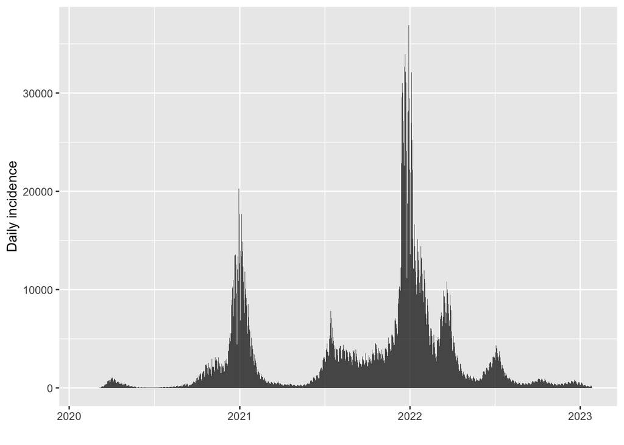

```r
plot(i) +
  scale_x_date(date_labels = '%Y')
```

We can filter by date using two different methods: 1. Using square brackets and numerical index, e.g. `i[1:20]` will select the first twenty dates 2. Using specific date ranges, e.g. `subset(i, from = as.Date("2020-02-25"))` will select all dates after the 25th Feb 2020. We can also use both `to =` and `from =` to pick upper and lower bounds.

#### Task 1: Filtering data

- Create a new incidence object called `firstwave` by filtering to the first four months of the data (up to “2020-06-03”).
- Create another incidence object called `secondwave` by choosing a suitable start and end date (hint: have a look at your incidence plot for the entire range of dates).

```r
firstwave <- subset(i, to = '2020-06-03')
firstwave
```

```
## <incidence object>
## [32418 cases from days 2020-02-03 to 2020-06-03]
##
## $counts: matrix with 122 rows and 1 columns
## $n: 32418 cases in total
## $dates: 122 dates marking the left-side of bins
## $interval: 1 day
## $timespan: 122 days
## $cumulative: FALSE
```

```r
secondwave <- subset(i, from = '2020-08-03', to = '2021-05-03')
secondwave
```

```
## <incidence object>
## [700289 cases from days 2020-08-03 to 2021-05-03]
##
## $counts: matrix with 274 rows and 1 columns
## $n: 700289 cases in total
## $dates: 274 dates marking the left-side of bins
## $interval: 1 day
## $timespan: 274 days
## $cumulative: FALSE
```

## Estimating the growth rate and doubling time

We can estimate growth rates and doubling times using the `fit()` function (assuming an exponential growth/decline model), which also gives us the 95% confidence intervals.

#### Task 2: Fitting a model

- Estimate the growth rate and doubling time for the first half of your `firstwave` object by fitting an exponential growth model
- Estimate the growth rate and doubling time for the first half of your `secondwave` object by fitting an exponential growth model
- Use `plot()` to visually assess how good your model is for both cases

```r
# First wave
half_firstwave <- subset(firstwave, to = '2020-04-03') # Subset the first half
fit_firstwave <- fit(half_firstwave) # Fit the first half
fit_firstwave # See the fitted growth rate and doubling time
```

```
## <incidence_fit object>
##
## $model: regression of log-incidence over time
##
## $info: list containing the following items:
##   $r (daily growth rate):
## [1] 0.1581549
##
##   $r.conf (confidence interval):
##          2.5 %    97.5 %
## [1,] 0.1403531 0.1759567
##
##   $doubling (doubling time in days):
## [1] 4.382711
##
##   $doubling.conf (confidence interval):
##         2.5 %   97.5 %
## [1,] 3.939306 4.938596
##
##   $pred: data.frame of incidence predictions (45 rows, 5 columns)
```

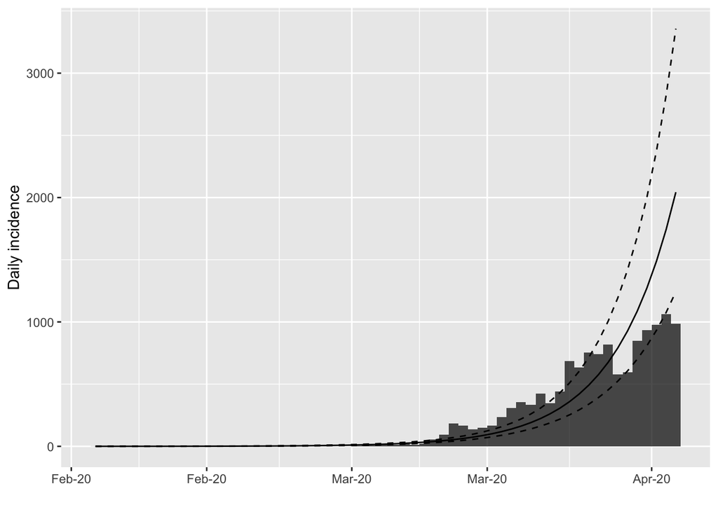

```r
pred_firstwave <- fit_firstwave$info$pred # Extract predictions with uncertainty

# Overlay predictions with incidence data
plot(half_firstwave) +
  geom_line(data = pred_firstwave, aes(x = dates, y = fit)) +
  geom_line(data = pred_firstwave, aes(x = dates, y = lwr),
            linetype = 'dashed') +
  geom_line(data = pred_firstwave, aes(x = dates, y = upr),
            linetype = 'dashed') +
  scale_x_date(date_labels = '%b-%y')
```

```r
# Second wave
half_secondtwave <- subset(secondwave, to = '2020-12-30') # Subset the 1st half
fit_secondwave <- fit(half_secondtwave) # Fit the first half
fit_secondwave # See the fitted growth rate and doubling time
```

```
## <incidence_fit object>
##
## $model: regression of log-incidence over time
##
## $info: list containing the following items:
##   $r (daily growth rate):
## [1] 0.0312441
##
##   $r.conf (confidence interval):
##           2.5 %     97.5 %
## [1,] 0.02979628 0.03269192
##
##   $doubling (doubling time in days):
## [1] 22.1849
##
##   $doubling.conf (confidence interval):
##        2.5 %   97.5 %
## [1,] 21.2024 23.26288
##
##   $pred: data.frame of incidence predictions (150 rows, 5 columns)
```

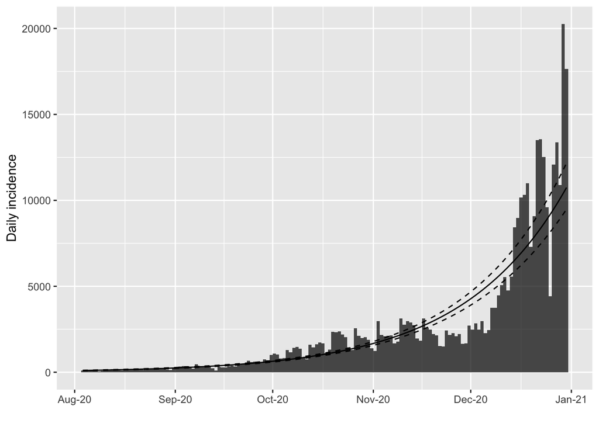

```r
pred_secondwave <- fit_secondwave$info$pred # Extract predictions w/uncertainty

# Overlay predictions with incidence data
plot(half_secondtwave) +
  geom_line(data = pred_secondwave, aes(x = dates, y = fit)) +
  geom_line(data = pred_secondwave, aes(x = dates, y = lwr),
            linetype = 'dashed') +
  geom_line(data = pred_secondwave, aes(x = dates, y = upr),
            linetype = 'dashed') +
  scale_x_date(date_labels = '%b-%y')
```

As well as filtering our dataset, we can also use the `split = as.Date("...")` argument to split the dataset into “before” and “after” and get estimates of the growth rate and doubling time for both periods. There’s also the function `fit_optim_split()`, which will pick the optimal split date for the model.

#### Task 3: Fitting a split model

- Choose a date you think might be appropriate and use `fit()` and the `split =` argument to get estimates of the growth rate for before and after your chosen date.
- Use the `fit_optim_split()` function to fit the model and find the optimal date and the growth rates for before and after. How close is the optimal date to your guess?

```r
# Let's do it for the second wave!
# Split argument
fit_secondwave_split <- fit(secondwave, split = '2020-12-30')
fit_secondwave_split
```

```
## <list of incidence_fit objects>
##
## attr(x, 'locations'): list of vectors with the locations of each incidence_fit object
##
## 'before'
## 'after'
##
## $model: regression of log-incidence over time
##
## $info: list containing the following items:
##   $r (daily growth rate):
##      before       after
##  0.03124410 -0.03447672
##
##   $r.conf (confidence interval):
##              2.5 %      97.5 %
## before  0.02979628  0.03269192
## after  -0.03664685 -0.03230659
##
##   $doubling (doubling time in days):
##  before
## 22.1849
##
##   $doubling.conf (confidence interval):
##          2.5 %   97.5 %
## before 21.2024 23.26288
##
##   $halving (halving time in days):
##    after
## 20.10479
##
##   $halving.conf (confidence interval):
##          2.5 %   97.5 %
## after 18.91424 21.45529
##
##   $pred: data.frame of incidence predictions (275 rows, 6 columns)
```

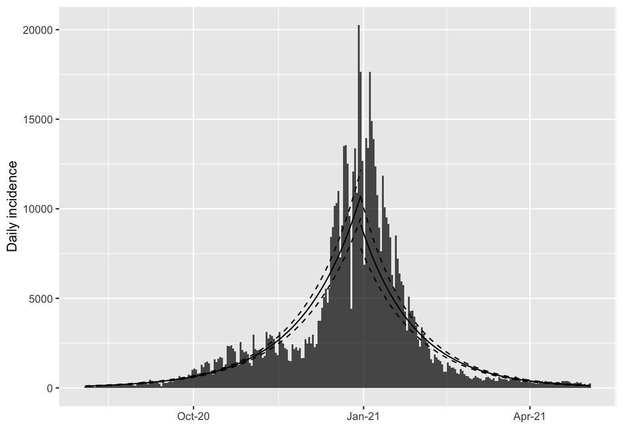

```r
pred_secondwave_split_before <- fit_secondwave_split$before$info$pred
pred_secondwave_split_after <- fit_secondwave_split$after$info$pred

plot(secondwave) +
  geom_line(data = pred_secondwave_split_before,
            aes(x = dates, y = fit), colour = 'black') +
  geom_line(data = pred_secondwave_split_before,
            aes(x = dates, y = lwr), linetype = 'dashed', colour = 'black') +
  geom_line(data = pred_secondwave_split_before,
            aes(x = dates, y = upr), linetype = 'dashed', colour = 'black') +
  geom_line(data = pred_secondwave_split_after,
            aes(x = dates, y = fit), colour = 'black') +
  geom_line(data = pred_secondwave_split_after,
            aes(x = dates, y = lwr), linetype = 'dashed', colour = 'black') +
  geom_line(data = pred_secondwave_split_after,
            aes(x = dates, y = upr), linetype = 'dashed', colour = 'black') +
  scale_x_date(date_labels = '%b-%y')
```

```r
# Optimal split (beware of overfitting)
fit_secondwave_optim_split <- fit_optim_split(secondwave)
optim_date <- fit_secondwave_optim_split$split

fit_secondwave_split_opsplit <- fit(secondwave, split = optim_date)
fit_secondwave_split_opsplit
```

```
## <list of incidence_fit objects>
##
## attr(x, 'locations'): list of vectors with the locations of each incidence_fit object
##
## 'before'
## 'after'
##
## $model: regression of log-incidence over time
##
## $info: list containing the following items:
##   $r (daily growth rate):
##      before       after
##  0.03059692 -0.03462677
##
##   $r.conf (confidence interval):
##              2.5 %      97.5 %
## before  0.02902785  0.03216599
## after  -0.03657257 -0.03268098
##
##   $doubling (doubling time in days):
##   before
## 22.65415
##
##   $doubling.conf (confidence interval):
##           2.5 %  97.5 %
## before 21.54907 23.8787
##
##   $halving (halving time in days):
##    after
## 20.01767
##
##   $halving.conf (confidence interval):
##          2.5 %  97.5 %
## after 18.95265 21.2095
##
##   $pred: data.frame of incidence predictions (275 rows, 6 columns)
```

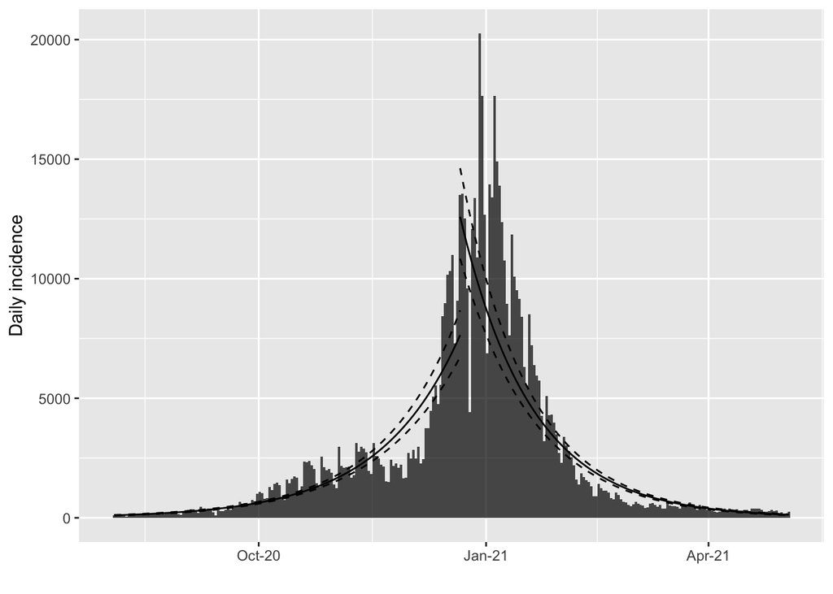

```r
fit_2wave_split_opsplit_before <- fit_secondwave_split_opsplit$before$info$pred
fit_2wave_split_opsplit_after <- fit_secondwave_split_opsplit$after$info$pred

plot(secondwave) +
  geom_line(data = fit_2wave_split_opsplit_before,
            aes(x = dates, y = fit), colour = 'black') +
  geom_line(data = fit_2wave_split_opsplit_before,
            aes(x = dates, y = lwr), linetype = 'dashed', colour = 'black') +
  geom_line(data = fit_2wave_split_opsplit_before,
            aes(x = dates, y = upr), linetype = 'dashed', colour = 'black') +
  geom_line(data = fit_2wave_split_opsplit_after,
            aes(x = dates, y = fit), colour = 'black') +
  geom_line(data = fit_2wave_split_opsplit_after,
            aes(x = dates, y = lwr), linetype = 'dashed', colour = 'black') +
  geom_line(data = fit_2wave_split_opsplit_after,
            aes(x = dates, y = upr), linetype = 'dashed', colour = 'black') +
  scale_x_date(date_labels = '%b-%y')
```

## Using `EpiEstim` to estimate the effective R number

To estimate the R number we need to have some knowledge of the distribution of either the serial interval (onset to onset) or the generation interval (infection to infection). The `EpiEstim` package has a function `estimate_R()` that uses the serial interval and incidence data to estimate the real-time value of the effective R number.

First we need to configure the serial interval distribution settings for this calculation, using the `make_config()` function, by providing a mean and a standard deviation for the serial interval.

```r
s_interval <- make_config(
  mean_si = 12.0,
  std_si = 5.2
)
```

Next, we use this as an input in the function `estimate_R()`.

#### Example:

```r
my_R <- estimate_R(i,method="parametric_si",config=s_interval)
```

```
## Default config will estimate R on weekly sliding windows.
##     To change this change the t_start and t_end arguments.
```

#### Task 4: Estimating R

- Estimate R for your `firstwave` and `secondwave` incidence objects
- Which date ranges have R greater than 1?
- Which date ranges have R less than 1?
- What do you think might have caused these changes in R?

```r
# write your code here
```